# Part II - Prosper Loan Data Insights Presentation

## by Lakshmi Madhuri Jeereddi

## Investigation Overview

In this part, I want investigate the varibles effcet the borrower APR and factore effect the monthly loan payment.

## Dataset Overview

The data set contains 84853 loan with 22 columns information like BorrowerAPR, ProsperScore, MonthlyLoanPayment, credit score, StatedMonthlyIncome and so on.

I created subset of the columns to 22 from 81 columns. looked for duplicate rows. converted datatypes of ListingCreationDate, ClosedDate, DateCreditPulled to datatime and seperated time from columns. Deleted the rows with out prosper score.

```python
# import all packages and set plots to be embedded inline
import numpy as np
import pandas as pd
import matplotlib.pyplot as plt
import seaborn as sb

%matplotlib inline

# suppress warnings from final output
import warnings
warnings.simplefilter("ignore")
```

```python
# load in the dataset into a pandas dataframe
df = pd.read_csv('prosperLoanData.csv')
```

```python
columns = ["ListingKey","ListingNumber","ListingCreationDate","ListingCategory (numeric)","LoanStatus","ClosedDate","Term","BorrowerAPR","BorrowerRate","ProsperRating (Alpha)","ProsperScore","Occupation","EmploymentStatus",
           "CreditScoreRangeLower","CreditScoreRangeUpper","DateCreditPulled","DebtToIncomeRatio","StatedMonthlyIncome","LoanOriginalAmount","MonthlyLoanPayment","AmountDelinquent","IncomeRange"]
loan = df[columns]
```

```python
loan[["ListingCreationDate","ClosedDate","DateCreditPulled"]] = loan[["ListingCreationDate","ClosedDate","DateCreditPulled"]].apply(pd.to_datetime)
loan['ListingCreationDate'] = pd.to_datetime(df['ListingCreationDate']).dt.date
loan['ClosedDate'] = pd.to_datetime(df['ClosedDate']).dt.date
loan['DateCreditPulled'] = pd.to_datetime(df['DateCreditPulled']).dt.date
```

```python
loan['DebtToIncomeRatio'] = loan['DebtToIncomeRatio'].fillna(loan['DebtToIncomeRatio'].mean())
loan = loan[loan['ProsperScore'].notnull()]
```

> Note that the above cells have been set as "Skip"-type slides. That means that when the notebook is rendered as http slides, those cells won't show up.

# Distribution of Borrower APR

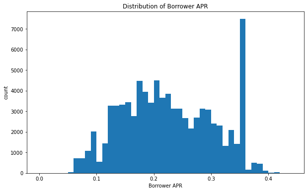

```python
plt.figure(figsize=[10,6])
bins =  np.arange(0, loan.BorrowerAPR.max()+0.02, 0.01)
plt.hist(loan['BorrowerAPR'], bins=bins)
plt.title('Distribution of Borrower APR')
plt.xlabel('Borrower APR')
plt.ylabel('count');
```

# Distribution of loan original amount

There are more number of loans with the amount of below 5000K and small number of loans in the amount from 20K to 35K.

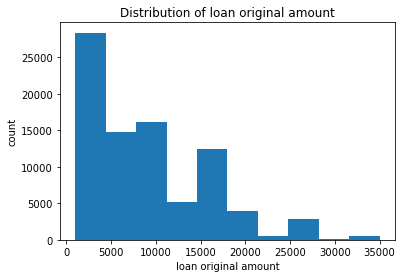

```python
plt.hist(loan['LoanOriginalAmount'])
plt.title('Distribution of loan original amount')
plt.xlabel('loan original amount')
plt.ylabel('count');
```

# Loan original amount Vs. Borrower APR

By seeing the data of the borrower APR and loan original amount. They have negative relationship. It means large amount of loans have low APR and smaller loans have large APR.

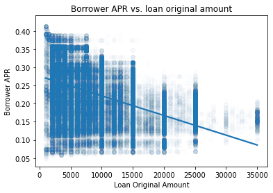

```python
sb.regplot(data=loan, x='LoanOriginalAmount',y='BorrowerAPR',scatter_kws={'alpha':0.01})
plt.title('Borrower APR vs. loan original amount')
plt.xlabel('Loan Original Amount')
plt.ylabel('Borrower APR');
```